# Reproducible Research: Peer Assignment 1

Divine Miho

Wednesday, February 11, 2015

Set the working directory

```r
setwd("~/Coursera/Reproducible_Research")
```

Load the required packages

```r
library(stats)
library(plyr)
library(lattice)
```

Load and manipulate the data

```r
dat <- read.csv("activity.csv")
```

Process/transform the data to a suitable format

```r
dat$date <- as.Date(dat$date, "%Y-%m-%d")
```

Summarize the dependent variable of interest, steps

```r
summary(dat$steps)
```

```
##    Min. 1st Qu.  Median    Mean 3rd Qu.    Max.    NA's
##    0.00    0.00    0.00   37.38   12.00  806.00    2304
```

```r
sum(dat$steps, na.rm=TRUE)
```

```
## [1] 570608
```

Histogram of the total number of steps taken each day

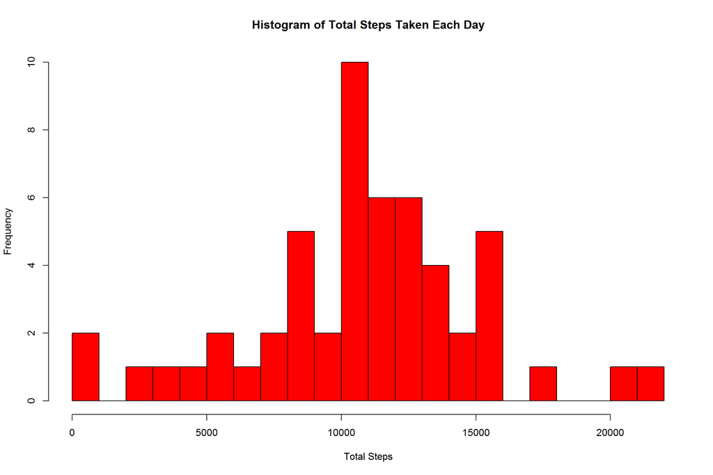

```r
totStps <-aggregate(dat$steps, by=list(dat$date), FUN=sum)
colnames(totStps) <- c("Date","total_steps")

h<-hist(totStps$total_steps, breaks=30, col="red",
        xlab="Total Steps",
        main="Histogram of Total Steps Taken Each Day")
```

Mean of the total steps taken each day

```r
mean(totStps$total_steps,na.rm = TRUE)
```

```
## [1] 10766.19
```

Median of the total steps taken each day

```r
median(totStps$total_steps,na.rm = TRUE)
```

```
## [1] 10765
```

Time series plot of five minute intervals and average number of steps taken

Get the data

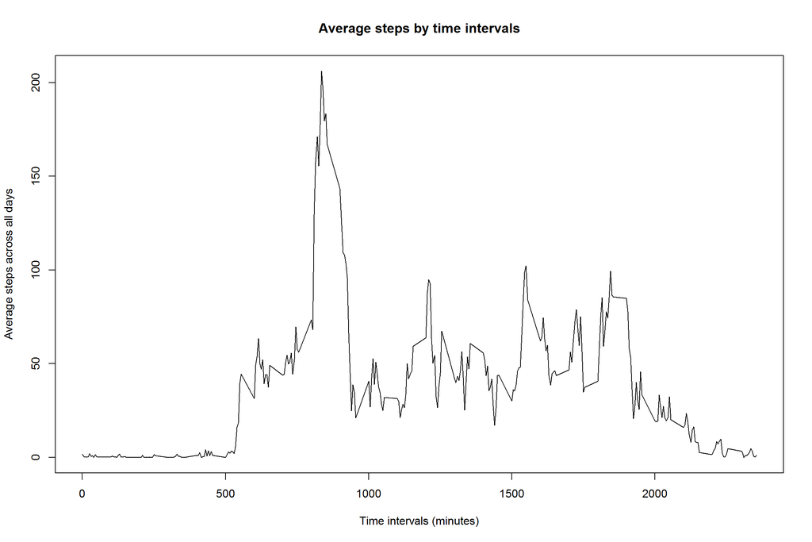

```r
aveStps <-aggregate(dat$steps, by=list(dat$interval), FUN=mean, na.rm= TRUE)
colnames(aveStps) <- c("interval","ave_steps")
with(aveStps, plot(interval,ave_steps, type = "l",
                   main = "Average steps by time intervals",
                   xlab = "Time intervals (minutes)",
                   ylab = "Average steps across all days"))
```

The five minute interval with the maximum numer of steps, on average

```r
which.max(aveStps[,2])
```

```
## [1] 104
```

```r
maxInt <- aveStps[aveStps$ave_steps == max(aveStps$ave_steps),]
```

Interval with max average total steps is 835

Since the data has missing values, I will be doing some imputation

I am replacing the missing values with the average total steps by interval

Count the number of rows with missing values

```r
sum(is.na(dat$steps))
```

```
## [1] 2304
```

Imputation

```r
impute.mean <- function(x) replace(x, is.na(x), mean(x, na.rm = TRUE))
dat2 <- ddply(dat, ~ interval, transform, steps = impute.mean(steps))
dat2 <- with(dat2, dat2[order(date,interval),])
```

Inorder to create a histogram, I need to aggregate steps by day

```r
totStps2 <-aggregate(dat2$steps, by=list(dat2$date), FUN=sum)
colnames(totStps2) <- c("Date","total_steps")
```

Histogram of the total number of steps taken each day

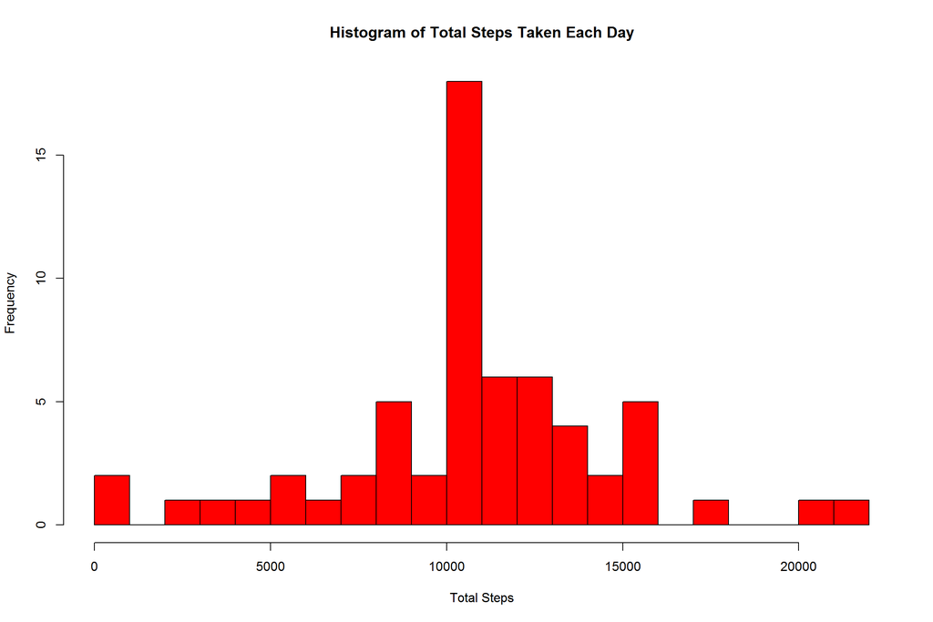

```r
h2<-hist(totStps2$total_steps, breaks=30, col="red",
         xlab="Total Steps",
         main="Histogram of Total Steps Taken Each Day")
```

I am plotting the two histograms together to see if the imputation made any difference to the distribution

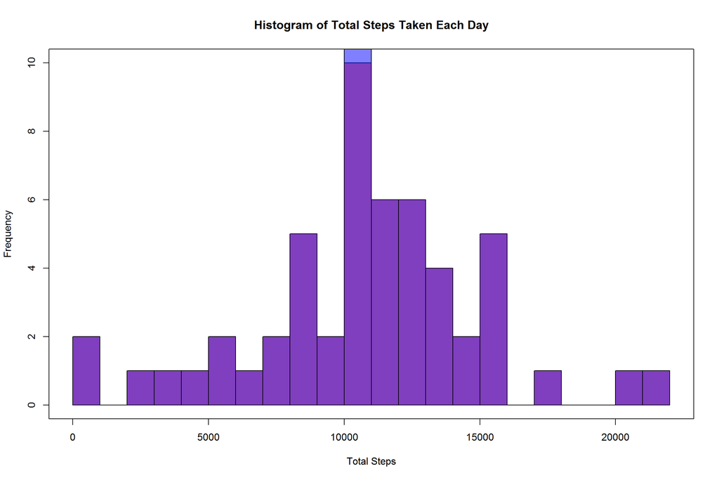

```r
hist(totStps$total_steps, col=rgb(1,0,0,0.5),breaks = 30,
     xlab="Total Steps", main="Histogram of Total Steps Taken Each Day")
hist(totStps2$total_steps, breaks = 30, col=rgb(0,0,1,0.5), add=T)
box()
```

```r
s1 <- summary(totStps2$total_steps)
m1 <- s1[[4]]
md1 <- s1[[3]]
s2 <- summary(totStps$total_steps)
m2 <- s2[[4]]
md2 <- s2[[3]]
```

Now I examine difference in activity between weekedays and weekends

First I create new factor variable for weekend and weekday dates

```r
dat2$wknd <- as.factor(ifelse(weekdays(dat2$date) %in% c("Saturday","Sunday"),
                              "Weekend","Weekday"))
```

Here is a panel plot comparing the total steps taken on the weekend vs. weekdays

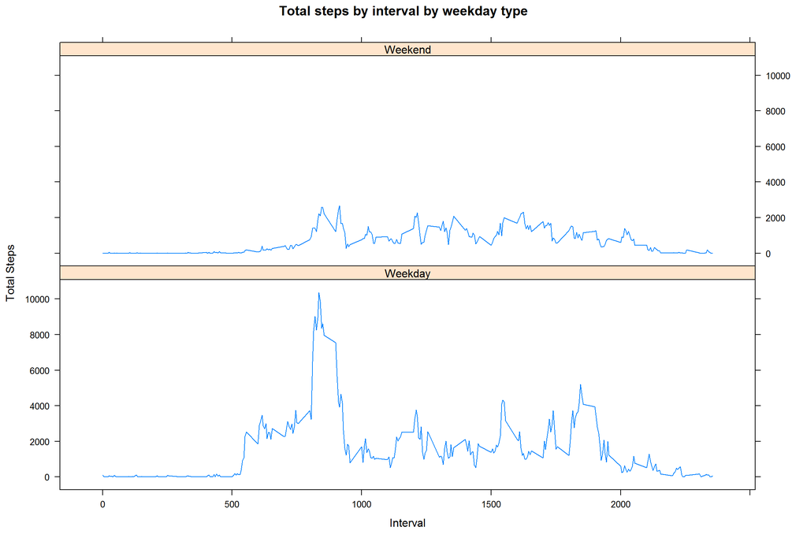

```r
dat3 <- ddply(dat2, c("wknd", "interval"), summarise,
              total_steps = sum(steps))

xyplot(total_steps~interval|wknd,dat3,type='l', cex = 0.3, layout = c(1, 2),
       xlab = 'Interval', ylab = 'Total Steps',
       main = "Total steps by interval by weekday type")
```